# BIOL 2209L: AI and energy

Ken Aho

2025-09-18

# 1 AI and LLMs

The term *Artificial intelligence* (AI) refers to the capacity of a computer to perform tasks typically associated with human intelligence (Wikipedia 2025a). The field of AI has several non-mutually-exclusive foci. These include:

- *Machine learning*, part of AI research since its beginning in 1956, machine leaallows a program to improve its performance on a given task automatically (Russell and Norvig 2021).
- *Machine perception* is the capacity of a computational device to receive and use input from sensors (Russell and Norvig 2021). Examples include software for speech recognition, image classification, and facial recognition.
- *Natural language processing* (NLP) describes the capacity of a computer program to read and communicate in human languages.

A number of recent developments, including *transformers* –a neural network framework that weighs the importance of text components and creates responses through a word embedding table (Wikipedia 2025d)– and *Large Language Models* (LLMs) –machine learning entities trained on a vast amount of text, for the purpose of language processing and language generation (Wikipedia 2025c)– have resulted in dramatic improvements in NLP performance. The most sophisticated LLMs are *Generative Pre-trained Transformer* (GPT) models. By 2023 GPT models were able to achieve human-level scores on the bar exam and the SAT test, among other applications (Bushwick 2023).

GPT models may generate biased reports –largely as a result of biased training data (Zack et al. 2024), and hallucinations (plausible-sounding random falsehoods)(Wikipedia 2025b). Despite these drawbacks, however, the capacity of GPT and other AI approaches to emulate (and potentially improve on) processes previously under human proprietorship is clear (and unnerving). Indeed, because of this potential, massive investments (mostly from entrenched software giants, e.g., Microsoft, Oracle, Meta, Google) have been made into AI-associated infrastructure, including the ongoing construction of new data centers and server farms (Van Der Vlist, Helmond, and Ferrari 2024). [Business Insider](https://www.businessinsider.com/us-data-center-construction-40-billion-spend-hits-record-high-2025-9) reported last week that data center construction costs in the US could total more than $1 trillion by 2028 (Fig 1.1).

[figure not shown]

Figure 1.1: A > $3.3 billion Microsoft data center under construction in Mt Pleasant Wisconsin. The first phase of the center will consume enough energy annually to power several hundred thousand homes.

As a result of these efforts, and the high energy use of GPT processes, energy demands of data centers are excepted to double globally by 2030 (Kolbert 2024). (De Vries 2023) estimated that if Google were to integrate generative AI into every search thread, its electricity usage rise to approximately $29 \times 10^9$ kilowatt-hours per year, exceeding the annual energy demand of many countries, including Kenya, Guatemala, and Croatia.

Today we will briefly explore GPT energy use in a lab using the Python programming language.

# 2 Python

[**Python**](https://www.python.org/) is a popular open source (free) programming language and computational environment. We will use Python today to help quantify the energy and carbon footprint of generative AI LLMs. We will run Python using Spyder, an Integrated Development Environment (IDE) for Python. There are a couple of preliminary steps.

- First, open Spyder by finding and clicking on its icon on your workstation:
- Next, you will need to specify the Python interpreter we will use in this lab. In Spyder, go to **Tools > Preferences > Python Interpreter** (Fig 2.1).

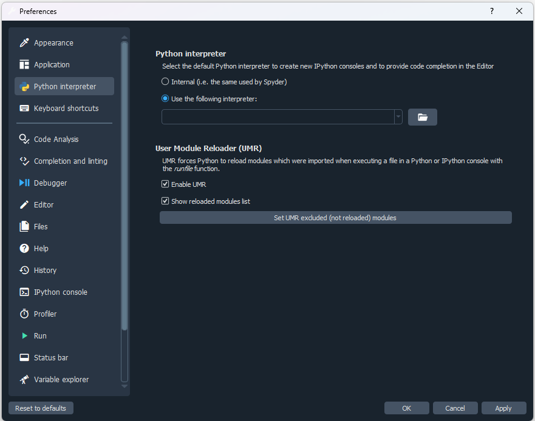

Figure 2.1: The Spyder Preferences interface.

- Next, click on the folder to right of the pulldown widget, and navigate to **C/Program Files/python313/python313.exe**. Hit **Apply**.
- Close Spyder and reopen it.

Now we can explore Python a bit. To start with, we can use Python as a calculator. Type `2 + 2` and click in the text editor component of Sypder (by default, the left hand side) .

```python
2 + 2
```

```
4
```

Like R –a language we will learn about later in the semester– Python is an Object Oriented Programming (OOP) language. Type:

```python
obj1 = 2 + 2
```

The result, 4, can be accessed by typing the object name: `obj1` (or whatever I named the object).

```python
obj1
```

```
4
```

Here I create a Python numerical array of the numbers, 1, 5, and 7, with help from the Python *numpy* package:

```python
import numpy as np
obj2 = np.array([1,5,7])
```

The line `import numpy as np` imports *numpy*, and allows me to call the package using the name `np`. The code `np.array` calls the function `array` in the *numpy* package.

I can use Python objects in various ways. For instance, here I add `obj1` and `obj2`, and take the log of the sum.

```python
np.log(obj1 + obj2)
```

```
array([1.60943791, 2.19722458, 2.39789527])
```

# 3 Computation of LLM Energy and Carbon Consumption

The [EcoLogits](https://ecologits.ai/latest/tutorial/) Python library tracks the energy consumption and environmental impacts of generative AI models.

The Python code below allows evaluation of energy consumption under the [OpenAI](https://openai.com/) generative AI framework. Other frameworks, e.g., [ChatGPT](https://chat.chatbot.app/), will be comparable.

```r
from ecologits import EcoLogits
from openai import OpenAI
import time

# Initialize EcoLogits
EcoLogits.init(providers=["openai"])

client = OpenAI(api_key="key")

# Make a generative AI query
response = client.chat.completions.create(
    model="gpt-4o-mini",
    messages=[
        {"role": "user", "content": "Tell me a funny joke!"}
    ]
)
```

The script above is contained in the file `codeecologits.py`. Download this file to your computer workstation and import into Spyder using **File > Open**, or simply paste the code into the Spyder text editor. If you do the latter, you will have to inset the code below in the place of `"key"` on line 8 above.

```r
"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"
```

Running the code I get:

```
The model architecture has not been released, expect lower precision. For further information visit https://ecologits.ai/tutorial/warnings_and_errors/#model-arch-not-released
The model architecture is multimodal, expect lower precision. For further information visit https://ecologits.ai/tutorial/warnings_and_errors/#model-arch-multimodal
```

We are told that our energy consumption results may be somewhat imprecise due to a lack of specific knowledge concerning the *OpenAI* model architecture, and multimodality in the predictions.

## 3.1 Response from query

The entity `response`, created on Line 10-14 above, is a complex Python object with many attributes. To get the AI reply to my query: `"Tell me a funny joke!"`, I can use:

```python
response.choices[0].message.content
```

```
"Why don't skeletons fight each other?\n\nThey don't have the guts!"
```

## 3.2 Primary energy

To get “primary energy” usage (the amount of energy consumed from natural sources such as raw fuels and other forms of energy, including waste), as the result of my query, I can use:

```python
response.impacts.pe
```

```
PE(type='PE', name='Primary Energy', value=RangeValue(min=0.00037285960168788627, max=0.0011162571865985878), unit='MJ')
```

Units above are MegaJoules = $10^6$ Joules. Recall that there are 4.184 Joules in a Calorie, and 1 Calorie is the amount of energy required to raise 1 gram of H<sub>2</sub>O 1 degree C.

## 3.3 Energy used

To get the minimum and maximum energy used in terms of direct electricity consumption of GPUs, server and other equipment from data centers, as a result of my query, I can use:

```python
response.impacts.energy
```

```
Energy(type='energy', name='Energy', value=RangeValue(min=3.565240466666666e-05, max=0.00010914194200000002), unit='kWh')
```

Note that energy units here are kilowatt hours.

## 3.4 CO<sub>2</sub> produced

```python
response.impacts.usage.energy.unit
```

```
'kWh'
```

To get the CO<sub>2</sub> production equivalent resulting from the query we can use:

```python
response.impacts.gwp
```

```
GWP(type='GWP', name='Global Warming Potential', value=RangeValue(min=2.237203248607196e-05, max=6.650495932081786e-05), unit='kgCO2eq')
```

Note that the units are kilograms of equivalent CO<sub>2</sub>.